# Spatial Point Patterns

Intensity Function

Yang Li

2026-05-20

# Definition of Intensity

The **intensity function** of a spatial point pattern, $\lambda(u)$, measures the expected number of points per unit area near location $u$. It is defined as

$$\lambda(u) = \lim_{|du|\to 0} \frac{E[N(du)]}{du}.$$

where $du$ is a small region containing the point $u$.

# Homogeneous Intensity

A point process is **homogeneous** if the intensity is constant over space:

$$\lambda(u)=\lambda = \frac{E[N(A)]}{|A|}$$

The expected number of points in the observation window $A$ is

$$E[N(A)] = \lambda |A|.$$

If $n$ points are observed in $A$, then the constant intensity can be estimated by

$$\hat{\lambda} = \frac{n}{|A|}.$$

# Inhomogeneous Intensity

A point process is **inhomogeneous** if the intensity varies over space:

$$\lambda(u) \neq \lambda.$$

This means that some parts of the study region have higher expected point density than others.

For example, disease cases may be more common near an environmental risk source, or trees may be more common in areas with favorable soil conditions.

# Kernel Intensity Estimation

**Kernel intensity estimation** is a nonparametric approach to estimate the intensity function

$$\hat{\lambda}(u)
=
\sum_{i=1}^{n}
\frac{1}{h^2}
K\left(
\frac{u-x_i}{h}
\right),$$

where:

- $u$ is the location where intensity is estimated,
- $x_i$ is the location of point $i$,
- $K(\cdot)$ is a two-dimensional kernel function (Gaussian, Uniform, Triangular, Epanechnikov, etc),
- $h$ is the bandwidth or smoothing parameter.

**2D**

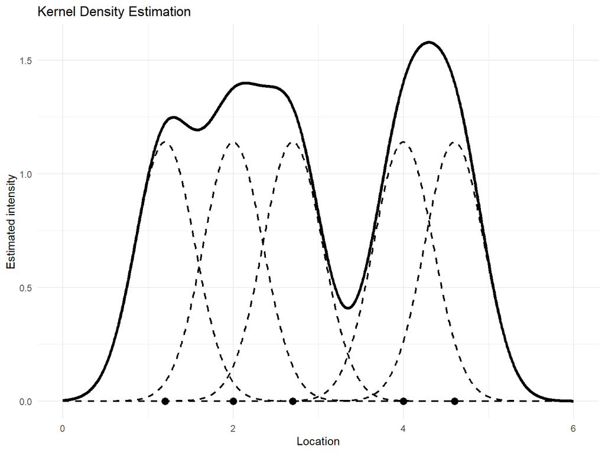

**3D**

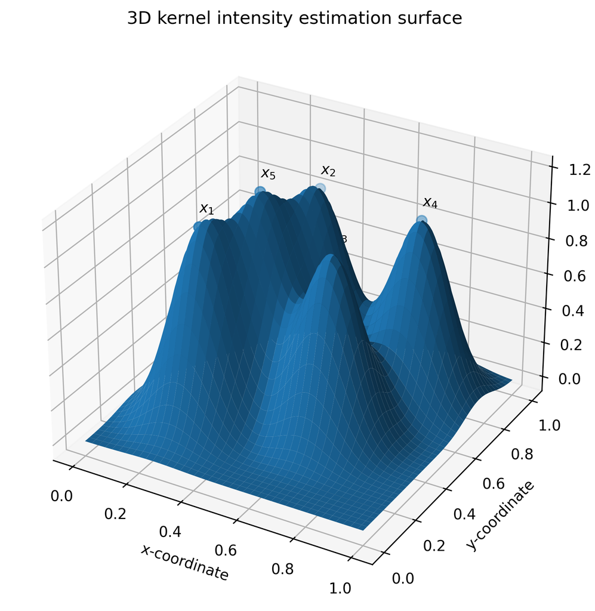

# Bandwidth

The bandwidth $h$ controls smoothness. It is crucial because too little smoothing can exaggerate random noise, while too much smoothing can hide meaningful spatial structure.

A small bandwidth gives a rougher surface:

$$\text{small } h \Rightarrow \text{less smoothing}.$$

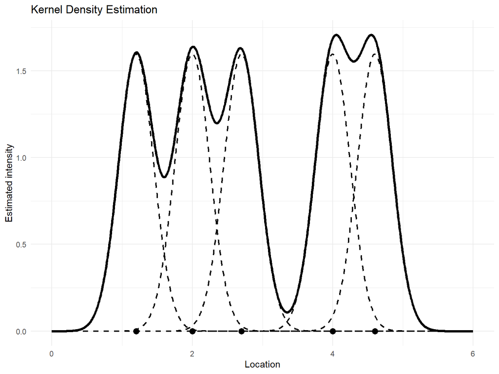

A large bandwidth gives a smoother surface:

$$\text{large } h \Rightarrow \text{more smoothing}.$$

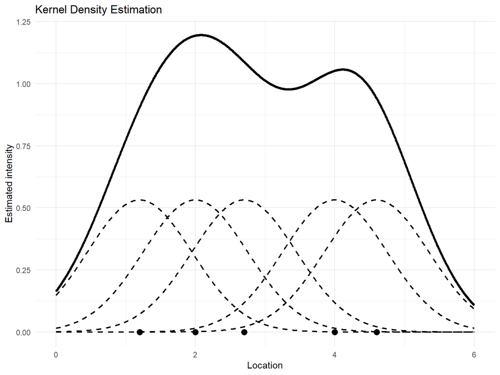

# Kernel Intensity Estimation in R

### Generate a Point Pattern

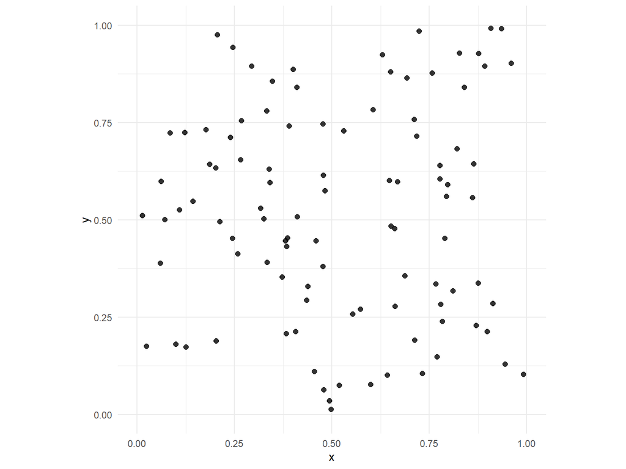

```r
suppressPackageStartupMessages({
  library(spatstat.geom)
  library(spatstat.random)
  library(spatstat.explore)
  library(ggplot2)
})

set.seed(1)

n_random <- 100

random_df <- data.frame(
  x = runif(n_random, 0, 1),
  y = runif(n_random, 0, 1),
  pattern = "Random"
)

ggplot(random_df, aes(x = x, y = y)) +
  geom_point(size = 2, alpha = 0.8) +
  coord_equal(xlim = c(0, 1), ylim = c(0, 1)) +
  labs(x = "x", y = "y") +
  theme_minimal()
```

```r
random_ppp <- ppp(
  x = random_df$x,
  y = random_df$y,
  window = owin(
    xrange = c(0, 1),
    yrange = c(0, 1)
  )
)
```

### Estimate the Intensity

The function `density.ppp()` computes a kernel-smoothed estimate of the intensity surface.

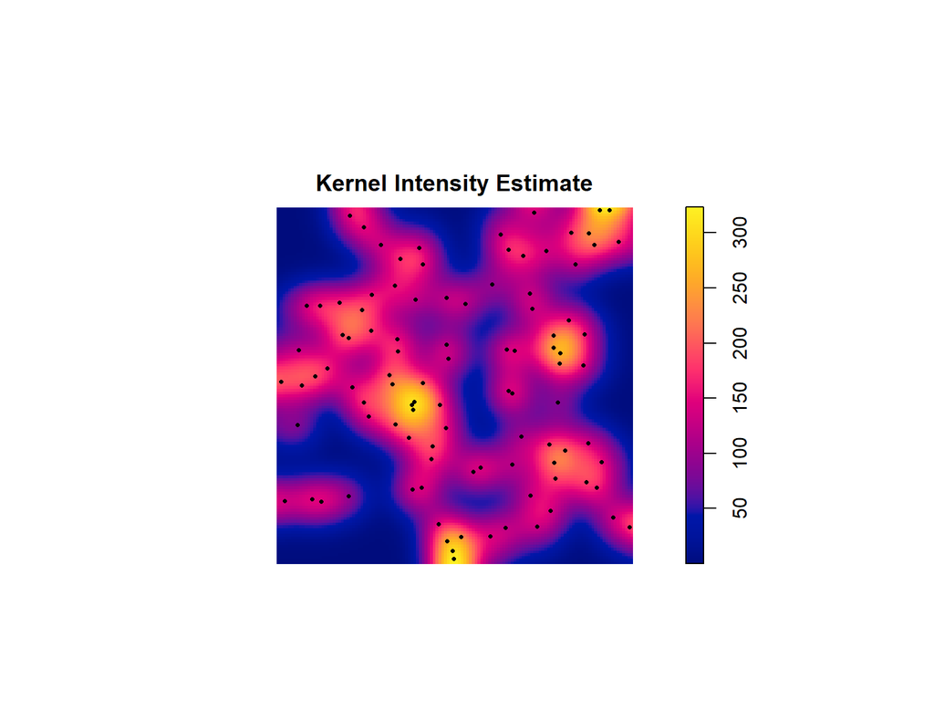

```r
lambda_hat <- density.ppp(random_ppp, sigma = 0.05)

plot(lambda_hat, main = "Kernel Intensity Estimate")
plot(random_ppp, add = TRUE, pch = 16, cex = 0.5)
```

Here, `sigma = 0.05` is the bandwidth.

# Comparing Bandwidths

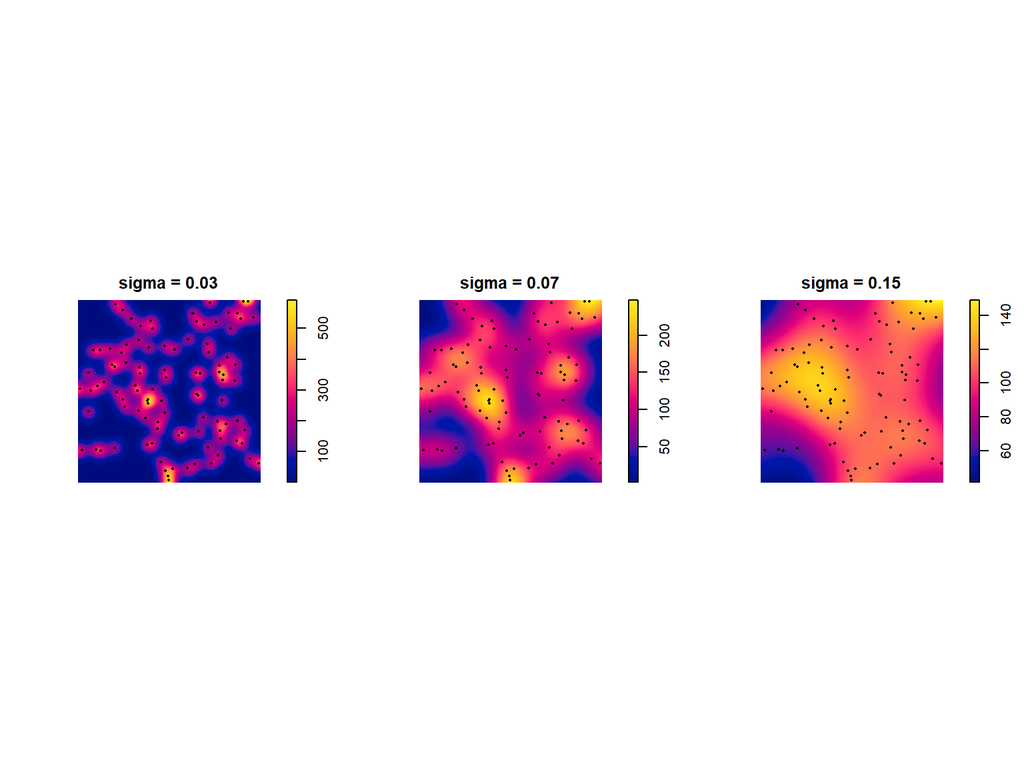

```r
par(mfrow = c(1, 3))

lambda_small <- density.ppp(random_ppp, sigma = 0.03)
lambda_medium <- density.ppp(random_ppp, sigma = 0.07)
lambda_large <- density.ppp(random_ppp, sigma = 0.15)

plot(lambda_small, main = "sigma = 0.03")
plot(random_ppp, add = TRUE, pch = 16, cex = 0.4)

plot(lambda_medium, main = "sigma = 0.07")
plot(random_ppp, add = TRUE, pch = 16, cex = 0.4)

plot(lambda_large, main = "sigma = 0.15")
plot(random_ppp, add = TRUE, pch = 16, cex = 0.4)
```

```r
par(mfrow = c(1, 1))
```

The smaller bandwidth produces a more local estimate. The larger bandwidth produces a smoother estimate.

# Automatic Bandwidth Selection

Instead of manually choosing the bandwidth, we can use an automatic bandwidth selection method. One option in `spatstat` is `bw.diggle()`. It uses cross validation to minimize the mean-square error criterion.

```r
bw <- bw.diggle(random_ppp)

bw
```

```
##      sigma
## 0.06090998
```

Use the selected bandwidth:

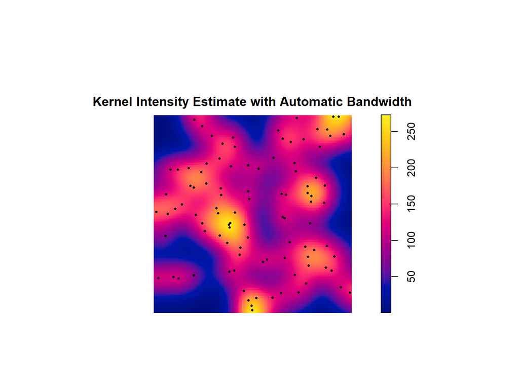

```r
lambda_auto <- density.ppp(random_ppp, sigma = bw)

plot(lambda_auto, main = "Kernel Intensity Estimate with Automatic Bandwidth")
plot(random_ppp, add = TRUE, pch = 16, cex = 0.5)
```